# Wrangling Data 3: factors, dates and functions

Matthew Bracher-Smith

2024-10-21

## Anonymous Feedback | Course content

**Use the QR code, [this](https://app.sli.do/event/7U7WjJ1tDSu9tLcWzkFxoR) link or type code #3267575 into slido.com**

[figure not shown]

## Overview

[figure not shown]

[figure not shown]

## Setup

Please install and load the following packages for today

```r
library(forcats)
library(ggplot2)
library(dplyr)
library(lubridate)
library(testthat)
library(gapminder)
```

## Review

- dplyr verbs, tidyr, joins, stringr
- homework

## Significantly More Important Review

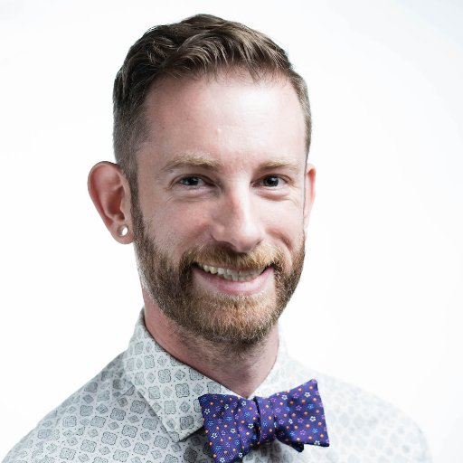

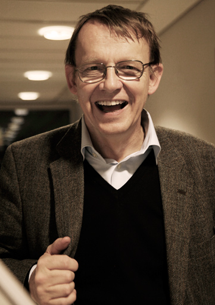

## The Plan

- Factors and Forcats
- Dates and Lubridate
- Functions and conditionals

# Factors

## Factors

A factor:

- is how we store categorical variables in R
- contains a fixed and known set of possible values

We can create them using the `factor()` function, which takes the format: **factor(vector, levels, labels)**

```r
# e.g.
factor(c(0, 1, 1, 1, 0), labels=c('Female', 'Male'))
```

```
[1] Female Male   Male   Male   Female
Levels: Female Male
```

## Making Factors

We can make factors that have an inherent order

```r
monthLevels <- c("Jan", "Feb", "Mar", "Apr", "May", "Jun",
                 "Jul", "Aug", "Sep", "Oct", "Nov", "Dec")
data <- factor(c("Dec", "Jun", "Apr"))
data
```

```
[1] Dec Jun Apr
Levels: Apr Dec Jun
```

But sorting them may not give us what we expect

```r
sort(data)
```

```
[1] Apr Dec Jun
Levels: Apr Dec Jun
```

## Making Factors

- Factors always have an *internal* order, even if you don’t give one
- If you don’t set the levels, they will be alphabetical
- If you want a specific order, you need to give it:

```r
monthLevels <- c("Jan", "Feb", "Mar", "Apr", "May", "Jun",
                 "Jul", "Aug", "Sep", "Oct", "Nov", "Dec")
data <- factor(c("Dec", "Jun", "Apr"), levels = monthLevels)
sort(data)
```

```
[1] Apr Jun Dec
Levels: Jan Feb Mar Apr May Jun Jul Aug Sep Oct Nov Dec
```

## Making Factors

Strings that aren’t in your levels are *silently* set as NA

```r
factor(c("Dec", "Jum", "Apr"), levels = monthLevels)
```

```
[1] Dec  <NA> Apr
Levels: Jan Feb Mar Apr May Jun Jul Aug Sep Oct Nov Dec
```

By contrast, readr’s `parse_factor()` will warn you

```r
readr::parse_factor(c("Dec", "Jum", "Apr"), levels = monthLevels)
```

```
[1] Dec  <NA> Apr
attr(,"problems")
# A tibble: 1 × 4
    row   col expected           actual
  <int> <int> <chr>              <chr>
1     2    NA value in level set Jum
Levels: Jan Feb Mar Apr May Jun Jul Aug Sep Oct Nov Dec
```

## Factors Practice

- create a factor vector called ‘marauders’ that contains the strings ‘moony’, ‘wormtail’, ‘padfoot’ and ‘prongs’ in alphabetical order
- create a factor called ‘patronus’ with the strings ‘stag’, ‘dog’, ‘otter’, creating levels from the order they appear in the input vector
- print only the levels of these factors

**Using diamonds**

- use `dplyr::count()` to show how many rows there are for each factor level in the ‘cut’ column. Is it any different to using `forcats::fct_count()`?
- use `dplyr::arrange(desc())` to sort the cut column in descending order. What were the rows sorted by?

## Why should I care?

1. you’re better than that
2. plots
3. models
4. forcats

## Why use the Forcats* package?

- It enables a lot of the common needs we have with factors
- It works well with ggplot2 (also written by Hadley/the tidyverse team)
- It generally tries to warn you when something may be wrong
- It has the word cats in it
- It’s an anagram of factors
- It’s **for cat**egorical**s** (factors)
- Something about cats

*strictly for humans

## fct_inorder()

`fct_inorder()`

```r
# sets the levels to be the
# order they appear in the vector
head(fct_inorder(gss_cat$marital))
```

```
[1] Never married Divorced      Widowed       Never married Divorced
[6] Married
Levels: Never married Divorced Widowed Married Separated No answer
```

## fct_relevel()

`fct_relevel()`

```r
# moves one or more levels to the start
head(fct_relevel(gss_cat$marital, 'Married'))
```

```
[1] Never married Divorced      Widowed       Never married Divorced
[6] Married
Levels: Married No answer Never married Separated Divorced Widowed
```

## fct_recode()

For changing the names of existing levels *by hand*

```r
myFactor <- factor(c("M", "F", "O", "M", "P", "M",
                     "F", "F", "F", "M", "O", "P"))
myFactorPub <- fct_recode(myFactor, male = "M", female = "F",
                          unknown = "O", unknown = "P")
myFactorPub
```

```
 [1] male    female  unknown male    unknown male    female  female  female
[10] male    unknown unknown
Levels: female male unknown
```

## fct_reorder()

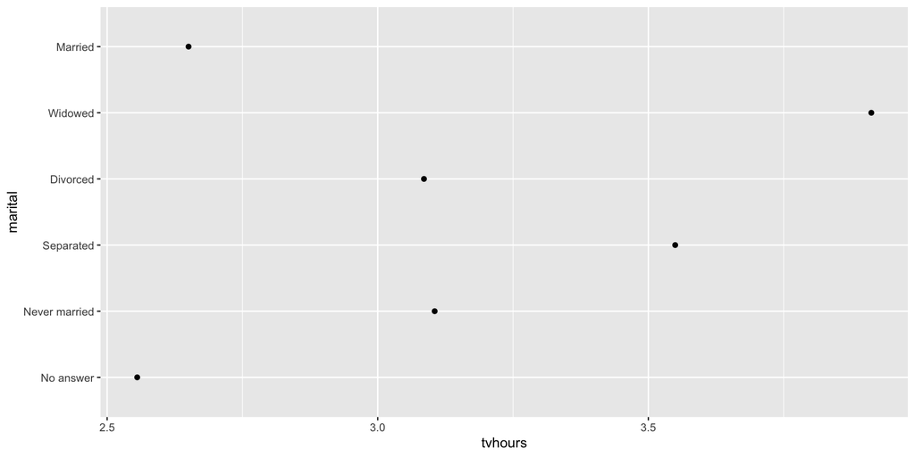

## fct_reorder()

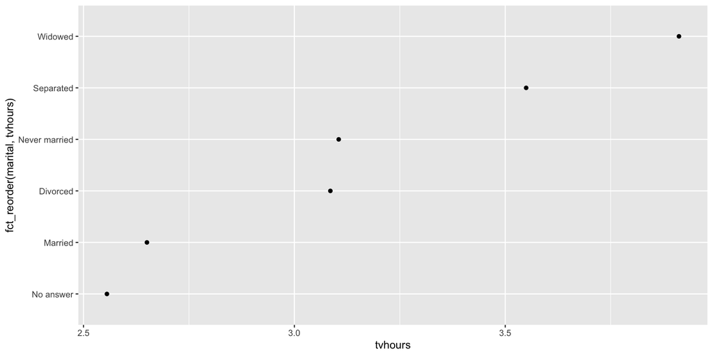

## fct_reorder()

- the most useful (in my opinion)
- reorder your factor levels by another variable
- allows you to bring structure to plots

```r
gss_cat |>
    group_by(marital) |>
    summarise(tvhours = mean(tvhours, na.rm = TRUE)) |>
    ggplot(aes(tvhours, fct_reorder(marital, tvhours))) + # <<<---
      geom_point()
```

## Forcats - Practice!

**Using gss_cat**

- how many levels are there in the ‘relig’ column?
- reorder the levels of ‘denom’ in order of appearance
- take the code below which plots income by age. Try changing the order of the levels in ‘rincome’ to be sorted by ‘age’. Now try just moving n/a to the start. Which option works best?

```r
gss_cat |>
  group_by(rincome) |>
  summarise(
    age = mean(age, na.rm = TRUE),
    tvhours = mean(tvhours, na.rm = TRUE),
    n = n()) |>
  ggplot(aes(age, rincome)) +
    geom_point()
```

## fct_reorder2()

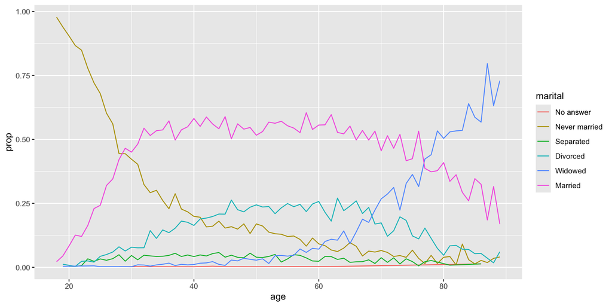

## fct_reorder2()

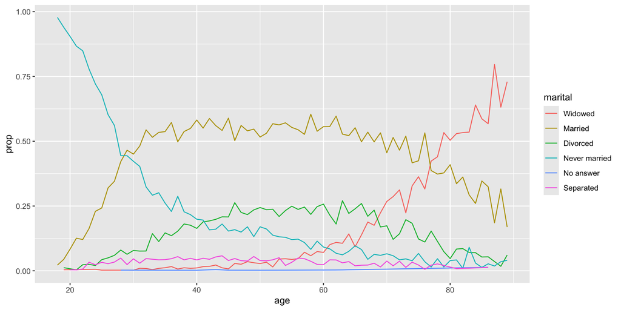

## fct_reorder2()

- probably the second most useful
- suprisingly helpful when reading graphs

```r
gss_cat |>
  filter(!is.na(age)) |>
  count(age, marital) |>
  group_by(age) |>
  mutate(prop = n / sum(n)) |>
  ggplot(aes(age, prop, colour = fct_reorder2(marital, age, prop))) + # <<<---
    geom_line() +
    labs(colour = "marital")
```

## Other useful Forcats functions

- `fct_rev()` reverses the order of the levels
- `fct_lump()` combines least common factor levels into ‘other’
- `fct_expand()` adds new levels to your factors
- `fct_relabel()` *automatically* relabels factor levels
- `fct_infreq()` order factors from most frequent to least frequent

## Forcats - More Practice!

**Using gss_cat**

- change the names of the levels of partyid from “Not str republican”, “Ind,near dem” and “Ind,near rep” to “Not strong republican”, “Independent, near democrat” and “Independent, near republican”
- run the code chunk below and view the output. Now edit the code so that the bars are sorted from lowest to highest using `fct_infreq()` and `fct_rev()`

```r
gss_cat |>
  ggplot(aes(marital)) +
    geom_bar()
```

## Forcats - Still More Practice!

- change the code below so that the legend colours match the order of the lines at the right side of the plot

```r
diamonds |>
  filter(color == 'J', depth > 55, carat <=2.5) |>
  ggplot(aes(carat, price, col=cut)) +
    geom_line(alpha=0.6)
```

## Gotchas: coercing factors

Errors may be obvious:

```r
x <- factor(c(1, 1, 0, 0, 1, 0, 1, 1, 1, 0))
as.numeric(x)
```

```
 [1] 2 2 1 1 2 1 2 2 2 1
```

## Gotchas: coercing factors

Or they can be more subtle:

```r
x <- factor(c(1, 1, 2, 5, 3, 3, 1, 6, 5, 1, 6, 2))
as.numeric(x)
```

```
 [1] 1 1 2 4 3 3 1 5 4 1 5 2
```

## Gotchas: coercing factors

- *NEVER* convert from factor to numeric unless you know that’s what you want
- It returns R’s internal codes for the factors, not their values
- Instead, **convert to character first**, *then* to numeric, i.e.:

```r
x <- factor(c(1, 1, 2, 5, 3, 3, 1, 6, 5, 1, 6, 2))
as.numeric(as.character(x))
```

```
 [1] 1 1 2 5 3 3 1 6 5 1 6 2
```

# Dates

## Dates

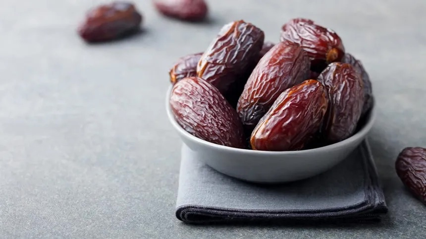

## How Dates Work in R

- Dates and times are **not just strings**, they have **many formats** like `YYYY-MM-DD`, `MM/DD/YYYY`, or even `DD-MM-YYYY`.
- Handling dates involves dealing with **varied formats**, time zones, leap years, and calculations between dates
- R has special packages to parse and manage dates efficiently.

```r
class("2024-10-20") # a simple date string
```

```
[1] "character"
```

```r
class(as.Date("2024-10-20")) # a date object
```

```
[1] "Date"
```

```r
typeof(as.Date("2024-10-20")) # but a double under the hood
```

```
[1] "double"
```

## Introduction to lubridate

- lubridate is an R package designed to make working with dates and times easier
- It helps parse different date formats, manipulate dates, and perform calculations.
- It’s just not possible to be accurate in handling dates without a dedicated date package
- But with lubridate, you can:
  - parse dates from strings in common formats
  - do arithmetic with dates easily
  - account for time zones, leap years etc.
  - handle times too (though we don’t cover that here)

## lubridate::functions()

- `ymd()` converts strings to dates in the format `YYYY-MM-DD` (year-month-day)
- it returns a date object, which is a special type of object in R
- there are several related functions which parse slightly different formats, such as `mdy()`, `dmy()`, `ymd_hms()` etc.
- `today()` returns the current date
- `year()`, `month()`, `day()` extract the year, month, and day from a date object

## lubridate::functions()

- `interval()` creates an interval between two dates
- we can pass this to `time_length()`, which calculates the length of an interval in a specified unit

```r
# Create two date objects
start_date <- ymd("2015-05-15")
end_date <- ymd("2024-10-20")
date_interval <- interval(start_date, end_date)

print(time_length(date_interval, "years"))
```

```
[1] 9.43287671233
```

## lubridate::practice()

- John Doe was born on 4th September, 1983. Create a date object for his birth date
- How old was John on the 6th June, 2020?
- What about today?

**using the `lakers` dataset which comes with lubridate**

- choose the correct function to replace `some_function` below:

```r
lakers |>
  as_tibble() |>
  mutate(date = some_function(sprintf("%08d", date)))
```

## lubridate::practice_more()

**using the economics dataset from ggplot2**

- take the date column from the economics dataset and create two new columns which contain the year and month of each date
- create a new column called time_since_nyse, which contains the number of years between the founding of the New York Stock Exchange on 17th May, 1792 and the date column

## Anonymous Feedback | Comments

**Use the QR code, [this](https://app.sli.do/event/7U7WjJ1tDSu9tLcWzkFxoR) link or type code #3267575 into slido.com**

[figure not shown]

# Functions

## Functions

Functions in R:

- allow you to automate tasks in a more powerful way than copy/paste
- mean you only need to update code in one place
- reduce the likelihood of errors
- are for others, but mainly for **YOU**
- should be written for **readability** and **reusability**
- have the format

```r
function_name <- function(arg1, arg2, arg3) {
  # function body
}
```

## Functions - Practice!

*call your functions after creating them to check their output*

- write an empty function with no arguments, called ‘stub_func’.
- write a function that takes no arguments and returns the number 3 using the `return()` statement. Choose an appropriate name.
- create another function with no return statement or arguments, which only contains the number 3. Run the function. Is it different to before?
- create a function called `my_divide()` which takes two arguments, ‘x’ and ‘y’ and returns x divided by y. Use an explicit return statement.
- we want to still return a value when y is zero. Change the `my_divide()` function so that there is another argument called ‘tol’. Set it to a very low value, and add it to y before dividing.

## General Rules for Writing Functions

Try to decipher the following code below - what does it do? - does it work? Are there errors?

```r
df <- data.frame(a = rnorm(10), b = rnorm(10), c = rnorm(10), d = rnorm(10))
df$a <- (df$a - min(df$a, na.rm = TRUE)) / (max(df$a, na.rm = TRUE) - min(df$a, na.rm = TRUE))
df$b <- (df$b - min(df$b, na.rm = TRUE)) / (max(df$b, na.rm = TRUE) - min(df$a, na.rm = TRUE))
df$c <- (df$c - min(df$c, na.rm = TRUE)) / (max(df$c, na.rm = TRUE) - min(df$c, na.rm = TRUE))
df$d <- (df$d - min(df$d, na.rm = TRUE)) / (max(df$d, na.rm = TRUE) - min(df$d, na.rm = TRUE))
```

## General Rules for Writing Functions

Is this better?

```r
rescale <- function(x) {
    return((x - min(x, na.rm = TRUE)) / (max(x, na.rm = TRUE) - min(x, na.rm = TRUE)))
}
```

## General Rules for Writing Functions

Even better?

```r
rescale <- function(x) {
    y <- min(x, na.rm = TRUE)
    return((x - y) / (max(x, na.rm = TRUE) - y))
}
```

## General Rules for Writing Functions

Perfect?

```r
rescale <- function(x) {
  # rescale vector to the range from 0 to 1
  min_value <- min(x, na.rm = TRUE)
  return((x - min_value) / (max(x, na.rm = TRUE) - min_value))
}
```

## General Rules for Writing Functions

- *never* take variables created *outside* a function and use them from *inside* a function unless you pass them as an argument
- if you have a lot of functions, it’s good practice to put them in a separate file and use ‘source’
- generally, functions should do one thing, but you can do whatever you like, including nested functions

## When to write a function

- if you find yourself writing/pasting the same thing 2/3 times

## When NOT to write a function

- if it’s a one-off bit of code you’ll never use again
- you’re lazy
- you hate future you

## Anonymous functions

- sometimes we need to package up some code in a function, but we know we’ll never need it again
- this is common where we do something trivial, like a simple calculation
- in these cases we often create a function *on the fly* in the call to another function
- these are called *anonymous functions* (because we don’t name them) or *lambda functions* (from lambda calculus)
- they’re reasonably common in R, especially when using dplyr

## Anonymous functions

- you’ve already seen these in calls to functions like `summarise()`!
- the tilde (`~`) is used to create a lambda function, and the dot (`.x`) is used to refer to the input
- you will also see `.` used to refer to the input - this is the same as `.x`
- you can actually use anything you like, but `.` and `.x` are common conventions

```r
# example use of an anonymous function with summarise
gapminder |>
  group_by(continent) |>
  summarise(across(where(is.numeric), ~ mean(.x, na.rm = TRUE))) |>
  head(3)
```

| continent | year | lifeExp | pop | gdpPercap |
| --- | --- | --- | --- | --- |
| Africa | 1979.5 | 48.8653301282 | 9916003.14263 | 2193.75457829 |
| Americas | 1979.5 | 64.6587366667 | 24504794.99667 | 7136.11035559 |
| Asia | 1979.5 | 60.0649032323 | 77038721.97222 | 7902.15042805 |

## Anonymous functions

- In this way,

```r
~ mean(.x, na.rm = TRUE)
```

is equivalent to

```r
function(.x) {
  mean(.x, na.rm = TRUE)
}
```

# Flow control: conditionals

## if-else statements

`if` statements have the format:

```r
if (condition) {
  # code executed when condition is TRUE
} else {
  # code executed when condition is FALSE
}
```

## if-else statements

We can add multiple `else if` statements to these

```r
if (x > 0) {
    print("Positive")
} else if (x < 0) {
    print("Negative")
} else {
    print("Zero")
}
```

## if-else statements

- `ifelse()` lets us use vectorised if-else statements (note, dplyr has a version called `dplyr::if_else()` that’s a bit stricter)
- if you have a lot of if statements, check out the `switch()` function
- `dplyr::case_when()` handles multiple vectorised `if_else()` statements

```r
# example use of case_when to simplify multiple if_else statements
gapminder |>
  mutate(lifeExp_category = case_when(
    lifeExp < 50 ~ "Low",
    lifeExp >= 50 & lifeExp <= 70 ~ "Medium",
    lifeExp > 70 ~ "High"
  )) |>
  head(3)
```

| country | continent | year | lifeExp | pop | gdpPercap | lifeExp_category |
| --- | --- | --- | --- | --- | --- | --- |
| Afghanistan | Asia | 1952 | 28.801 | 8425333 | 779.4453145 | Low |
| Afghanistan | Asia | 1957 | 30.332 | 9240934 | 820.8530296 | Low |
| Afghanistan | Asia | 1962 | 31.997 | 10267083 | 853.1007100 | Low |

# Using your functions

## Using your functions

- modularising code
- unit testing
- packages

## Modularising code

- separating code into functions and files makes it easier to re-use across projects
- it also makes it easier to maintain as we know where to go to change them
- testing functions is also easier than testing code spread out in a script and interweaved with results

## Modularising code - practice!

- create a new R script
- create a function in the script called `my_add()` that takes two arguments, `x` and `y` and returns their sum (do not paste it into the terminal!)
- save the R script
- in the console, source the R script with `source("path/to/script.R")`
- run the function with `my_add(2, 3)`

## Types of testing

- there are many ways to test your code! We have:
  - **unit tests** in your local development environment or CI/CD pipeline
  - **integration tests** to check that your code works with other code
  - **quality assurance tests** to check that your code meets a certain standard (usually done by a separate team)
  - **end-to-end tests** to check that your code works in a real-world (production) environment

## Unit Testing

- for testing the smallest unit of code (functions)
- they are simply functions that test your code to make sure it does what it is supposed to
- this can mean it gives the correct output with expected input, but also that it errors as expected when you give it faulty input
- allows you to change your code and quickly check it still works
- allows you to sleep at night
- done in r using the `testthat` package

## Unit testing - practice!

- create a function called `my_multiply()` that takes two arguments, `x` and `y` and returns their product
- write a test for this function that checks that `my_multiply(2, 3)` returns 6
- use the example of my_add below and modify it:

```r
my_add <- function(x, y) {
  return(x + y)
}

testthat::test_that("my_add() works as expected",
{
  testthat::expect_equal(my_add(2, 3), 5)
})
```

## Putting it all together (optional extra homework)

- create a github account
- install `devtools` and `testthat`
- make a personal package following the outline [here](https://r-pkgs.org/whole-game.html)
- add a function to the package for a common task you do (can be simple)
- write test for your function using `testthat`
- push it to github and (double optional) send me the link!

## Putting it all together (optional extra homework)

- this:
  - is a great way to learn how to write functions and test them
  - it will set you up for future projects
  - is entirely optional and not required for the course

## Homework

- Quarto file and optional reading below
- [A history of stringsAsFactors](https://simplystatistics.org/posts/2015-07-24-stringsasfactors-an-unauthorized-biography/)
- [Background to factors](https://peerj.com/preprints/3163/)
- [Anonymous functions](https://www.r-bloggers.com/anonymous-functions-in-r-and-python/)
- [More information on unit tests](http://r-pkgs.had.co.nz/tests.html)